# Part: 1

## Chapter: 1

### Section: 1.1

```python
1 + 5 * 2 - 3
```

```
8
```

```python
1 +
```

```
  Cell In[2], line 1
    1 +
       ^
SyntaxError: invalid syntax
```

### Section: 1.2

```python
import nltk
nltk.download()
```

```
NLTK Downloader
---------------------------------------------------------------------------
    d) Download   l) List    u) Update   c) Config   h) Help   q) Quit
---------------------------------------------------------------------------
```

```
Download which package (l=list; x=cancel)?
```

[output not shown]

[output not shown]

[output cut: 294 more lines]

[output not shown]

```
---------------------------------------------------------------------------
    d) Download   l) List    u) Update   c) Config   h) Help   q) Quit
---------------------------------------------------------------------------
```

```
True
```

```python
from nltk.book import *
```

```
*** Introductory Examples for the NLTK Book ***
Loading text1, ..., text9 and sent1, ..., sent9
Type the name of the text or sentence to view it.
Type: 'texts()' or 'sents()' to list the materials.
text1: Moby Dick by Herman Melville 1851
text2: Sense and Sensibility by Jane Austen 1811
text3: The Book of Genesis
text4: Inaugural Address Corpus
text5: Chat Corpus
text6: Monty Python and the Holy Grail
text7: Wall Street Journal
text8: Personals Corpus
text9: The Man Who Was Thursday by G . K . Chesterton 1908
```

```python
text1
```

```
<Text: Moby Dick by Herman Melville 1851>
```

```python
text2
```

```
<Text: Sense and Sensibility by Jane Austen 1811>
```

### Section: 1.3

```python
text1.concordance('monstrous')
```

```
Displaying 11 of 11 matches:
ong the former , one was of a most monstrous size . ... This came towards us ,
ON OF THE PSALMS . " Touching that monstrous bulk of the whale or ork we have r
ll over with a heathenish array of monstrous clubs and spears . Some were thick
d as you gazed , and wondered what monstrous cannibal and savage could ever hav
that has survived the flood ; most monstrous and most mountainous ! That Himmal
they might scout at Moby Dick as a monstrous fable , or still worse and more de
th of Radney .'" CHAPTER 55 Of the Monstrous Pictures of Whales . I shall ere l
ing Scenes . In connexion with the monstrous pictures of whales , I am strongly
ere to enter upon those still more monstrous stories of them which are to be fo
ght have been rummaged out of this monstrous cabinet there is no telling . But
of Whale - Bones ; for Whales of a monstrous size are oftentimes cast up dead u
```

```python
text1.similar('monstrous')
```

```
true contemptible christian abundant few part mean careful puzzled
mystifying passing curious loving wise doleful gamesome singular
delightfully perilous fearless
```

```python
text2.similar('monstrous')
```

```
very so exceedingly heartily a as good great extremely remarkably
sweet vast amazingly
```

```python
text2.common_contexts(['monstrous', 'very'])
```

```
am_glad a_pretty a_lucky is_pretty be_glad
```

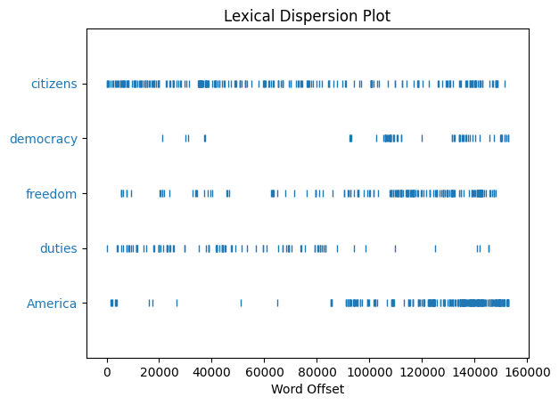

```python
text4.dispersion_plot(['citizens', 'democracy', 'freedom', 'duties', 'America'])
```

```python
text3.generate()
```

```
Building ngram index...
```

```
laid by her , and said unto Cain , Where art thou , and said , Go to ,
I will not do it for ten ' s sons ; we dreamed each man according to
their generatio the firstborn said unto Laban , Because I said , Nay ,
but Sarah shall her name be . , duke Elah , duke Shobal , and Akan .
and looked upon my affliction . Bashemath Ishmael ' s blood , but Isra
for as a prince hast thou found of all the cattle in the valley , and
the wo The
```

```
"laid by her , and said unto Cain , Where art thou , and said , Go to ,\nI will not do it for ten ' s sons ; we dreamed each man according to\ntheir generatio the firstborn said unto Laban , Because I said , Nay ,\nbut Sarah shall her name be . , duke Elah , duke Shobal , and Akan .\nand looked upon…
```

### Section: 1.4

```python
len(text3)
```

```
44764
```

```python
# Absurdly long so I'm sortening it
sorted(set(text3))[:20]
```

```
['!',
 "'",
 '(',
 ')',
 ',',
 ',)',
 '.',
 '.)',
 ':',
 ';',
 ';)',
 '?',
 '?)',
 'A',
 'Abel',
 'Abelmizraim',
 'Abidah',
 'Abide',
 'Abimael',
 'Abimelech']
```

```python
len(set(text3)) / len(text3)
```

```
0.06230453042623537
```

```python
text3.count('smote')
```

```
5
```

```python
100 * text4.count('a') / len(text4)
```

```
1.457806031353621
```

```python
def lexical_diversity(text):
    return len(set(text)) / len(text)
def percentage(count, total):
    return 100 * count / total
```

```python
lexical_diversity(text3)
```

```
0.06230453042623537
```

```python
lexical_diversity(text5)
```

```
0.13477005109975562
```

```python
percentage(4, 5)
```

```
80.0
```

```python
percentage(text4.count('a'), len(text4))
```

```
1.457806031353621
```

### Section: 2.1

```python
sent1 = ['Call', 'me', 'Ismael']
sent1
```

```
['Call', 'me', 'Ismael']
```

```python
len(sent1)
```

```
3
```

```python
lexical_diversity(sent1)
```

```
1.0
```

```python
sent2
```

```
['The',
 'family',
 'of',
 'Dashwood',
 'had',
 'long',
 'been',
 'settled',
 'in',
 'Sussex',
 '.']
```

```python
sent3
```

```
['In',
 'the',
 'beginning',
 'God',
 'created',
 'the',
 'heaven',
 'and',
 'the',
 'earth',
 '.']
```

```python
['Monty', 'Python'] + ['and', 'the', 'Holy', 'Grail']
```

```
['Monty', 'Python', 'and', 'the', 'Holy', 'Grail']
```

```python
sent4 + sent1
```

```
['Fellow',
 '-',
 'Citizens',
 'of',
 'the',
 'Senate',
 'and',
 'of',
 'the',
 'House',
 'of',
 'Representatives',
 ':',
 'Call',
 'me',
 'Ismael']
```

```python
sent1.append('Some')
sent1
```

[output not shown]

### Section: 2.2

```python
text4[173]
```

```
'awaken'
```

```python
text4.index('awaken')
```

```
173
```

```python
text5[16715:16735]
```

```
['U86',
 'thats',
 'why',
 'something',
 'like',
 'gamefly',
 'is',
 'so',
 'good',
 'because',
 'you',
 'can',
 'actually',
 'play',
 'a',
 'full',
 'game',
 'without',
 'buying',
 'it']
```

```python
text6[1600:1625]
```

```
['We',
 "'",
 're',
 'an',
 'anarcho',
 '-',
 'syndicalist',
 'commune',
 '.',
 'We',
 'take',
 'it',
 'in',
 'turns',
 'to',
 'act',
 'as',
 'a',
 'sort',
 'of',
 'executive',
 'officer',
 'for',
 'the',
 'week']
```

```python
sent = ['word1', 'word2', 'word3', 'word4', 'word5', 'word6', 'word7', 'word8', 'word9', 'word10']
```

```python
sent[0]
```

```
'word1'
```

```python
sent[9]
```

```
'word10'
```

```python
sent[10]
```

```
---------------------------------------------------------------------------
IndexError                                Traceback (most recent call last)
Cell In[43], line 1
----> 1 sent[10]

IndexError: list index out of range
```

```python
sent[5:8]
```

```
['word6', 'word7', 'word8']
```

```python
sent[5]
```

```
'word6'
```

```python
sent[6]
```

```
'word7'
```

```python
sent[7]
```

```
'word8'
```

```python
sent[:3]
```

```
['word1', 'word2', 'word3']
```

```python
text2[141525:]
```

```
['among',
 'the',
 'merits',
 'and',
 'the',
 'happiness',
 'of',
 'Elinor',
 'and',
 'Marianne',
 ',',
 'let',
 'it',
 'not',
 'be',
 'ranked',
 'as',
 'the',
 'least',
 'considerable',
 ',',
 'that',
 'though',
 'sisters',
 ',',
 'and',
 'living',
 'almost',
 'within',
 'sight',
 'of',
 'each',
 'other',
 ',',
 'they',
 'could',
 'live',
 'without',
 'disagreement',
 'between',
 'themselves',
 ',',
 'or',
 'producing',
 'coolness',
 'between',
 'their',
 'husbands',
 '.',
 'THE',
 'END']
```

```python
sent[0] = 'First'
sent[9] = 'Last'
len(sent)
```

```
10
```

```python
sent[1:9] = ['Second', 'Third']
sent
```

[output not shown]

```python
sent[9]
```

```
---------------------------------------------------------------------------
IndexError                                Traceback (most recent call last)
Cell In[55], line 1
----> 1 sent[9]

IndexError: list index out of range
```

### Section: 2.3

```python
sent1 = ['Call', 'me', 'Ishmael', '.']
my_sent = ['Bravely', 'bold', 'Sir', 'Robin', ',', 'rode', 'forth', 'from', 'Camelot', '.']
noun_phrase = my_sent[1:4]
noun_phrase
```

```
['bold', 'Sir', 'Robin']
```

```python
w0rDs = sorted(noun_phrase)
w0rDs
```

```
['Robin', 'Sir', 'bold']
```

```python
not = 'Camelot'
```

```
  Cell In[62], line 1
    not = 'Camelot'
        ^
SyntaxError: invalid syntax
```

```python
vocab = set(text1)
vocab_size = len(vocab)
vocab_size
```

```
19317
```

### Section: 2.4

```python
name = 'Monty'
name[0]
```

```
'M'
```

```python
name[:4]
```

```
'Mont'
```

```python
name * 2
```

```
'MontyMonty'
```

```python
name + '!'
```

```
'Monty!'
```

```python
' '.join(['Monty', 'Python'])
```

```
'Monty Python'
```

```python
'Monty Python'.split()
```

```
['Monty', 'Python']
```

### Section: 3.1

```python
fdist1 = FreqDist(text1)
print(fdist1)
```

```
<FreqDist with 19317 samples and 260819 outcomes>
```

```python
fdist1.most_common(50)
```

```
[(',', 18713),
 ('the', 13721),
 ('.', 6862),
 ('of', 6536),
 ('and', 6024),
 ('a', 4569),
 ('to', 4542),
 (';', 4072),
 ('in', 3916),
 ('that', 2982),
 ("'", 2684),
 ('-', 2552),
 ('his', 2459),
 ('it', 2209),
 ('I', 2124),
 ('s', 1739),
 ('is', 1695),
 ('he', 1661),
 ('with', 1659),
 ('was', 1632),
 ('as', 1620),
 ('"', 1478),
 ('all', 1462),
 ('for', 1414),
 ('this', 1280),
 ('!', 1269),
 ('at', 1231),
 ('by', 1137),
 ('but', 1113),
 ('not', 1103),
 ('--', 1070),
 ('him', 1058),
 ('from', 1052),
 ('be', 1030),
 ('on', 1005),
 ('so', 918),
 ('whale', 906),
 ('one', 889),
 ('you', 841),
 ('had', 767),
 ('have', 760),
 ('there', 715),
 ('But', 705),
 ('or', 697),
 ('were', 680),
 ('now', 646),
 ('which', 640),
 ('?', 637),
 ('me', 627),
 ('like', 624)]
```

```python
fdist1['whale']
```

```
906
```

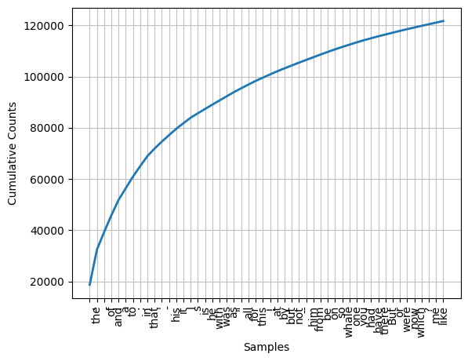

```python
fdist1.plot(50, cumulative=True)
```

### Section: 3.2

```python
V = set(text1)
long_words = [w for w in V if len(w) > 15]
sorted(long_words)
```

```
['CIRCUMNAVIGATION',
 'Physiognomically',
 'apprehensiveness',
 'cannibalistically',
 'characteristically',
 'circumnavigating',
 'circumnavigation',
 'circumnavigations',
 'comprehensiveness',
 'hermaphroditical',
 'indiscriminately',
 'indispensableness',
 'irresistibleness',
 'physiognomically',
 'preternaturalness',
 'responsibilities',
 'simultaneousness',
 'subterraneousness',
 'supernaturalness',
 'superstitiousness',
 'uncomfortableness',
 'uncompromisedness',
 'undiscriminating',
 'uninterpenetratingly']
```

```python
fdist5 = FreqDist(text5)
sorted(w for w in set(text5) if len(w) > 7 and fdist5[w] > 7)
```

```
['#14-19teens',
 '#talkcity_adults',
 '((((((((((',
 '........',
 'Question',
 'actually',
 'anything',
 'computer',
 'cute.-ass',
 'everyone',
 'football',
 'innocent',
 'listening',
 'remember',
 'seriously',
 'something',
 'together',
 'tomorrow',
 'watching']
```

### Section: 3.3

```python
list(bigrams(['more', 'is', 'said', 'than', 'done']))
```

```
[('more', 'is'), ('is', 'said'), ('said', 'than'), ('than', 'done')]
```

```python
text4.collocations()
```

```
United States; fellow citizens; years ago; four years; Federal
Government; General Government; American people; Vice President; God
bless; Chief Justice; one another; fellow Americans; Old World;
Almighty God; Fellow citizens; Chief Magistrate; every citizen; Indian
tribes; public debt; foreign nations
```

```python
text8.collocations()
```

```
would like; medium build; social drinker; quiet nights; non smoker;
long term; age open; Would like; easy going; financially secure; fun
times; similar interests; Age open; weekends away; poss rship; well
presented; never married; single mum; permanent relationship; slim
build
```

### Section: 3.4

```python
# Again, really long
[len(w) for w in text1][:10]
```

```
[1, 4, 4, 2, 6, 8, 4, 1, 9, 1]
```

```python
fdist = FreqDist(len(w) for w in text1)
print(fdist)
```

```
<FreqDist with 19 samples and 260819 outcomes>
```

```python
fdist
```

```
FreqDist({3: 50223, 1: 47933, 4: 42345, 2: 38513, 5: 26597, 6: 17111, 7: 14399, 8: 9966, 9: 6428, 10: 3528, ...})
```

```python
fdist.most_common()
```

```
[(3, 50223),
 (1, 47933),
 (4, 42345),
 (2, 38513),
 (5, 26597),
 (6, 17111),
 (7, 14399),
 (8, 9966),
 (9, 6428),
 (10, 3528),
 (11, 1873),
 (12, 1053),
 (13, 567),
 (14, 177),
 (15, 70),
 (16, 22),
 (17, 12),
 (18, 1),
 (20, 1)]
```

```python
fdist.max()
```

```
3
```

```python
fdist[3]
```

```
50223
```

```python
fdist.freq(3)
```

```
0.19255882431878046
```

### Section: 4.1

```python
sent7
```

```
['Pierre',
 'Vinken',
 ',',
 '61',
 'years',
 'old',
 ',',
 'will',
 'join',
 'the',
 'board',
 'as',
 'a',
 'nonexecutive',
 'director',
 'Nov.',
 '29',
 '.']
```

```python
[w for w in sent7 if len(w) < 4]
```

```
[',', '61', 'old', ',', 'the', 'as', 'a', '29', '.']
```

```python
[w for w in sent7 if len(w) <= 4]
```

```
[',', '61', 'old', ',', 'will', 'join', 'the', 'as', 'a', 'Nov.', '29', '.']
```

```python
[w for w in sent7 if len(w) == 4]
```

```
['will', 'join', 'Nov.']
```

```python
[w for w in sent7 if len(w) != 4]
```

```
['Pierre',
 'Vinken',
 ',',
 '61',
 'years',
 'old',
 ',',
 'the',
 'board',
 'as',
 'a',
 'nonexecutive',
 'director',
 '29',
 '.']
```

```python
sorted(w for w in set(text1) if w.endswith('ableness'))
```

```
['comfortableness',
 'honourableness',
 'immutableness',
 'indispensableness',
 'indomitableness',
 'intolerableness',
 'palpableness',
 'reasonableness',
 'uncomfortableness']
```

```python
sorted(term for term in set(text4) if 'gnt' in term)
```

```
['Sovereignty', 'sovereignties', 'sovereignty']
```

```python
# Long
sorted(item for item in set(text6) if item.istitle())[:20]
```

```
['A',
 'Aaaaaaaaah',
 'Aaaaaaaah',
 'Aaaaaah',
 'Aaaah',
 'Aaaaugh',
 'Aaagh',
 'Aaah',
 'Aaauggh',
 'Aaaugh',
 'Aaauugh',
 'Aagh',
 'Aah',
 'Aauuggghhh',
 'Aauuugh',
 'Aauuuuugh',
 'Aauuuves',
 'Action',
 'Actually',
 'African']
```

```python
sorted(item for item in set(sent7) if item.isdigit())
```

```
['29', '61']
```

```python
sorted(w for w in set(text7) if '-' in w and 'index' in w)
```

```
['Stock-index',
 'index-arbitrage',
 'index-fund',
 'index-options',
 'index-related',
 'stock-index']
```

```python
sorted(wd for wd in set(text3) if wd.istitle() and len(wd) > 10)
```

```
['Abelmizraim',
 'Allonbachuth',
 'Beerlahairoi',
 'Canaanitish',
 'Chedorlaomer',
 'Girgashites',
 'Hazarmaveth',
 'Hazezontamar',
 'Ishmeelites',
 'Jegarsahadutha',
 'Jehovahjireh',
 'Kirjatharba',
 'Melchizedek',
 'Mesopotamia',
 'Peradventure',
 'Philistines',
 'Zaphnathpaaneah']
```

```python
sorted(w for w in set(sent7) if not w.islower())
```

```
[',', '.', '29', '61', 'Nov.', 'Pierre', 'Vinken']
```

```python
sorted(t for t in set(text2) if 'cie' in t or 'cei' in t)
```

```
['ancient',
 'ceiling',
 'conceit',
 'conceited',
 'conceive',
 'conscience',
 'conscientious',
 'conscientiously',
 'deceitful',
 'deceive',
 'deceived',
 'deceiving',
 'deficiencies',
 'deficiency',
 'deficient',
 'delicacies',
 'excellencies',
 'fancied',
 'insufficiency',
 'insufficient',
 'legacies',
 'perceive',
 'perceived',
 'perceiving',
 'prescience',
 'prophecies',
 'receipt',
 'receive',
 'received',
 'receiving',
 'society',
 'species',
 'sufficient',
 'sufficiently',
 'undeceive',
 'undeceiving']
```

### Section: 4.2

```python
[len(w) for w in text1][:20]
```

```
[1, 4, 4, 2, 6, 8, 4, 1, 9, 1, 1, 8, 2, 1, 4, 11, 5, 2, 1, 7]
```

```python
[w.upper() for w in text1][:10]
```

```
['[',
 'MOBY',
 'DICK',
 'BY',
 'HERMAN',
 'MELVILLE',
 '1851',
 ']',
 'ETYMOLOGY',
 '.']
```

```python
len(text1)
```

```
260819
```

```python
len(set(text1))
```

```
19317
```

```python
len(set(word.lower() for word in text1))
```

```
17231
```

```python
len(set(word.lower() for word in text1 if word.isalpha()))
```

```
16948
```

### Section: 4.3

```python
word = 'cat'
if len(word) < 5:
    print('word length is less than 5')
```

```
word length is less than 5
```

```python
if len(word) >= 5:
    print('word length is greater than or equal to 5')
```

```python
for word in ['Call', 'me', 'Ishmael', '.']:
    print(word)
```

```
Call
me
Ishmael
.
```

### Section: 4.4

```python
sent1 = ['Call', 'me', 'Ishmael', '.']
for xyzzy in sent1:
    if xyzzy.endswith('l'):
        print(xyzzy)
```

```
Call
Ishmael
```

```python
for token in sent1:
    if token.islower():
        print(token, 'is a lowercase word')
    elif token.istitle():
        print(token, 'is a titlecase word')
    else:
        print(token, 'is punctuation')
```

```
Call is a titlecase word
me is a lowercase word
Ishmael is a titlecase word
. is punctuation
```

```python
tricky = sorted(w for w in set(text2) if 'cie' in w or 'cei' in w)
for word in tricky:
    print(word, end=' ')
```

```
ancient ceiling conceit conceited conceive conscience conscientious conscientiously deceitful deceive deceived deceiving deficiencies deficiency deficient delicacies excellencies fancied insufficiency insufficient legacies perceive perceived perceiving prescience prophecies receipt receive received …
```

## Chapter: 4

### Section: 4.1

```python
foo = 'Monty'
bar = foo
foo = 'Python'
bar
```

```
'Monty'
```

```python
foo = ['Monty', 'Python']
bar = foo
foo[1] = 'Bodkin'
bar
```

```
['Monty', 'Bodkin']
```

```python
empty = []
nested = [empty, empty, empty]
nested
```

```
[[], [], []]
```

```python
nested[1].append('Python')
nested
```

```
[['Python'], ['Python'], ['Python']]
```

```python
nested = [[]] * 3
nested[1].append('Python')
nested[1] = ['Monty']
nested
```

```
[['Python'], ['Monty'], ['Python']]
```

```python
size = 5
python = ['Python']
snake_nest = [python] * size
snake_nest[0] == snake_nest[1] == snake_nest[2] == snake_nest[3] == snake_nest[4]
```

```
True
```

```python
snake_nest[0] is snake_nest[1] is snake_nest[2] is snake_nest[3] is snake_nest[4]
```

```
True
```

```python
import random
position = random.choice(range(size))
snake_nest[position] = ['Python']
snake_nest
```

```
[['Python'], ['Python'], ['Python'], ['Python'], ['Python']]
```

```python
snake_nest[0] == snake_nest[1] == snake_nest[2] == snake_nest[3] == snake_nest[4]
```

```
True
```

```python
snake_nest[0] is snake_nest[1] is snake_nest[2] is snake_nest[3] is snake_nest[4]
```

```
False
```

```python
[id(snake) for snake in snake_nest]
```

```
[5988272768, 6037167680, 6037167680, 6037167680, 6037167680]
```

```python
mixed = ['cat', '', ['dog'], []]
for element in mixed:
    if element:
        print(element)
```

```
cat
['dog']
```

```python
animals = ['cat', 'dog']
if 'cat' in animals:
    print(1)
elif 'dog' in animals:
    print(2)
```

```
1
```

```python
sent = ['No', 'good', 'fish', 'goes', 'anywhere', 'without', 'a', 'porpoise', '.']
all(len(w) > 4 for w in sent)
```

```
False
```

```python
any(len(w) > 4 for w in sent)
```

```
True
```

### Section: 4.2

```python
t = 'walk', 'fem', 3
t
```

```
('walk', 'fem', 3)
```

```python
t[0]
```

```
'walk'
```

```python
t[1:]
```

```
('fem', 3)
```

```python
len(t)
```

```
3
```

```python
raw = 'I turned off the spectroroute'
text = ['I', 'turned', 'off', 'the', 'spectroroute']
pair = (6, 'turned')
raw[2], text[3], pair[1]
```

```
('t', 'the', 'turned')
```

```python
raw[-3:], text[-3:], pair[-3:]
```

```
('ute', ['off', 'the', 'spectroroute'], (6, 'turned'))
```

```python
len(raw), len(text), len(pair)
```

```
(29, 5, 2)
```

```python
raw = 'Red lorry, yellow lorry, red lorry, yellow lorry.'
text = nltk.word_tokenize(raw)
fdist = nltk.FreqDist(text)
sorted(fdist)
```

```
[',', '.', 'Red', 'lorry', 'red', 'yellow']
```

```python
for key in fdist:
    print(key + ':', fdist[key], end='; ')
```

```
lorry: 4; ,: 3; yellow: 2; Red: 1; red: 1; .: 1;
```

```python
words = ['I', 'turned', 'off', 'the', 'spectroroute']
# words[2], words[3], words[4] = words[3], words[4], words[2]
words
```

```
['I', 'turned', 'off', 'the', 'spectroroute']
```

```python
words = ['I', 'turned', 'off', 'the', 'spectroroute']
tags = ['noun', 'verb', 'prep', 'det', 'noun']
zip(words, tags)
list(zip(words, tags))
```

```
[('I', 'noun'),
 ('turned', 'verb'),
 ('off', 'prep'),
 ('the', 'det'),
 ('spectroroute', 'noun')]
```

```python
list(enumerate(words))
```

```
[(0, 'I'), (1, 'turned'), (2, 'off'), (3, 'the'), (4, 'spectroroute')]
```

```python
text = nltk.corpus.nps_chat.words()
cut = int(0.9 * len(text))
training_data, test_data = text[:cut], text[cut:]
text == training_data + test_data
```

```
True
```

```python
len(training_data) / len(test_data)
```

```
9.0
```

```python
words = 'I turned off the spectroroute'.split()
wordlens = [(len(word), word) for word in words]
wordlens.sort()
' '.join(w for (_, w) in wordlens)
```

```
'I off the turned spectroroute'
```

```python
lexicon = [
    ('the', 'det', ['Di:', 'D@']),
    ('off', 'prep', ['Qf', 'O:f'])
]
```

```python
lexicon.sort()
lexicon[1] = ('turned', 'VBD', ['t3:nd', 't3`nd'])
del lexicon[0]
```

```python
text = '''"When I use a word," Humpty Dumpty said in rather a scornful tone,
    "it means just what I choose it to mean - neither more nor less."'''
[w.lower() for w in nltk.word_tokenize(text)]
```

```
['``',
 'when',
 'i',
 'use',
 'a',
 'word',
 ',',
 "''",
 'humpty',
 'dumpty',
 'said',
 'in',
 'rather',
 'a',
 'scornful',
 'tone',
 ',',
 '``',
 'it',
 'means',
 'just',
 'what',
 'i',
 'choose',
 'it',
 'to',
 'mean',
 '-',
 'neither',
 'more',
 'nor',
 'less',
 '.',
 "''"]
```

```python
max([w.lower() for w in nltk.word_tokenize(text)])
```

```
'word'
```

```python
max(w.lower() for w in nltk.word_tokenize(text))
```

```
'word'
```

### Section: 4.3

```python
tokens = nltk.corpus.brown.words(categories='news')
count = 0
total = 0
for token in tokens:
    count += 1
    total += len(token)
total / count
```

```
4.401545438271973
```

```python
total = sum(len(t) for t in tokens)
print(total / len(tokens))
```

```
4.401545438271973
```

```python
word_list = []
i = 0
while i < len(tokens):
    j = 0
    while j < len(word_list) and word_list[j] <= tokens[i]:
        j += 1
    if j == 0 or tokens[i] != word_list[j - 1]:
        word_list.insert(j, tokens[i])
    i += 1
```

```python
word_list = sorted(set(tokens))
```

```python
fd = nltk.FreqDist(nltk.corpus.brown.words())
cumulative = 0.0
most_common_words = [word for (word, count) in fd.most_common()]
for rank, word in enumerate(most_common_words):
    cumulative += fd.freq(word)
    print('%3d %6.2f%% %s' % (rank + 1, cumulative * 100, word))
    if cumulative > 0.25:
        break
```

```
  1   5.40% the
  2  10.42% ,
  3  14.67% .
  4  17.78% of
  5  20.19% and
  6  22.40% to
  7  24.29% a
  8  25.97% in
```

```python
text = nltk.corpus.gutenberg.words('milton-paradise.txt')
longest = ''
for word in text:
    if len(word) > len(longest):
        longest = word
longest
```

```
'unextinguishable'
```

```python
maxlen = max(len(word) for word in text)
[word for word in text if len(word) == maxlen]
```

```
['unextinguishable',
 'transubstantiate',
 'inextinguishable',
 'incomprehensible']
```

```python
sent = ['The', 'dog', 'gave', 'John', 'the', 'newspaper']
n = 3
[sent[i:i+n] for i in range(len(sent) - n + 1)]
```

```
[['The', 'dog', 'gave'],
 ['dog', 'gave', 'John'],
 ['gave', 'John', 'the'],
 ['John', 'the', 'newspaper']]
```

```python
m, n = 3, 7
array = [[set() for i in range(n)] for j in range(m)]
array[2][5].add('Alice')
import pprint
pprint.pprint(array)
```

```
[[set(), set(), set(), set(), set(), set(), set()],
 [set(), set(), set(), set(), set(), set(), set()],
 [set(), set(), set(), set(), set(), {'Alice'}, set()]]
```

```python
array = [[set()] * n] * m
array[2][5].add(7)
pprint.pprint(array)
```

```
[[{7}, {7}, {7}, {7}, {7}, {7}, {7}],
 [{7}, {7}, {7}, {7}, {7}, {7}, {7}],
 [{7}, {7}, {7}, {7}, {7}, {7}, {7}]]
```

### Section: 4.4

```python
import re
def get_text(file):
    """Read text, normalize, what not"""
    text = open(file).read()
    text = re.sub(r'<.*?>', ' ', text)
    text = re.sub('\\s+', ' ', text)
    return text
```

```python
help(get_text)
```

```
Help on function get_text in module __main__:

get_text(file)
    Read text, normalize, what not
```

```python
def repeat(msg, num):
    return ' '.join([msg] * num)
monty = 'Monty Python'
repeat(monty, 3)
```

```
'Monty Python Monty Python Monty Python'
```

```python
def monty():
    return 'Monty Python'
monty()
```

```
'Monty Python'
```

```python
repeat(monty(), 3)
```

```
'Monty Python Monty Python Monty Python'
```

```python
repeat('Monty Python', 3)
```

```
'Monty Python Monty Python Monty Python'
```

```python
def my_sort1(mylist):
    mylist.sort()
def my_sort2(mylist):
    return sorted(mylist)
def my_sort3(mylist):
    mylist.sort()
    return mylist
```

```python
def set_up(word, properties):
    word = 'lolcat'
    properties.append('noun')
    properties = 5

w = ''
p = []
set_up(w, p)
w
```

```
''
```

```python
p
```

```
['noun']
```

```python
w = ''
word = w
word = 'lolcat'
w
```

```
''
```

```python
p = []
properties = p
properties.append('noun')
properties = 5
p
```

```
['noun']
```

```python
def tag(word):
    if word in ['a', 'the', 'all']:
        return 'det'
    else:
        return 'noun'
tag('the')
```

```
'det'
```

```python
tag('knight')
```

```
'noun'
```

```python
tag(["'Tis", 'but', 'a', 'scratch'])
```

```
'noun'
```

```python
def tag(word):
    assert isinstance(word, basestring), "argument to tag() must be a string"
    if word in ['a', 'the', 'all']:
        return 'det'
    else:
        return 'noun'
```

```python
# idk, I can't find a mention of this function anywhere
data = load_corpus()
results = analyze(data)
present(results)
```

```
---------------------------------------------------------------------------
NameError                                 Traceback (most recent call last)
Cell In[210], line 1
----> 1 data = load_corpus()
      2 results = analyze(data)
      3 present(results)

NameError: name 'load_corpus' is not defined
```

# Part: 2

## Notebook: 01

> What is Tokenization?

The process of splitting raw text into relevant chunks.

> What does the Counter class do?

Counts the instances of elements in a given list.

> What are stop-words?

Words that have a high occurrence but don't provide much, if any, meaning on their own.

> What is text normalization?

Replacing tokens with a canonical, or standard form that is more consistent and connects those that might not be easily obvious as having the same purpose. Ex: Color, color, COLOR, colour. Technically, all of those are unique tokens, but are all practically the same.

> What are n-grams?

N-length sequence of adjacent terms.

## Notebook: 02

> What is the most common word found in the corpus from the PyconUK data abstracts?

`python`

> What is the most common bigram?

`(',', 'and')`

> What is the most common trigram?

`('.', 'This', 'talk')`

## Notebook: 03

**Run the first two code cells.**

> What is the probability value for sport? (It should be the first number after the 2nd code cell.)

`~0.5773` which is really close to "is," so that's a little sus.

**Now run the third code cell.**

> Now run that 2nd code cell again. Now what is the probability for the value sport? Why did it change?

Non of the cells presented this, and when I tried to run it by hand, everything died drastically.

## Notebook: 04

> How many times were functions declared (i.e., using the def keyword--lambda functions don't count)?

Non

> How many times were loops used (e.g., for or while loops--inline for loops don't count)?

Nada

> How many times did the print statements not use formatted output?

`6`

> What do you notice about the import statements? Where are they located?

Top of the segments, like non-heathens do. Alphabetical order, which, a little pretentious.

> What do you notice about the comment cells? How are they formatted?

The code is split up into line separated blocks, some preceded by comments. Single-line comments, though occasionally multiple single-line comments in a row.

## Notebook: 05

> How many times were functions declared (i.e., using the def keyword--lambda functions don't count)?

Zip

> How many times were loops used (e.g., for or while loops--inline for loops don't count)?

Zilch

> How many times did the print statements not use formatted output?

`10`

> What do you notice about the import statements? Where are they located?

Top of the segments, like non-heathens do. Alphabetical order, which, a little pretentious.

> What do you notice about the comment cells? How are they formatted?

The code is split up into line separated blocks, some preceded by comments. Single-line comments, though occasionally multiple single-line comments in a row.

## Final Question

> Based on what you have seen in these notebooks, what are some useful conventions for programming python in jupyter notebooks?

Being able to document your code to a hightened degree is pretty swag. That, plus you can isolate relavent pieces into their own segments and print the results for just that segment, rather than dumping the entire thing at once and having to add massive headers designating which part is which.